# Global Life Expectancy & Socioeconomic Factors

A Cross-National Descriptive Analysis Across 50 Countries

**Author:** Research & Data Analysis Group · **Data Sources:** World Bank & WHO (2023 Estimates) · **Date:** October 2026 · **Sample:** 50 Nations (5 Continents)

## 1. Introduction & Research Objectives

Life expectancy at birth serves as a foundational benchmark for measuring national living standards, sanitary conditions, and public healthcare capacity. Over the past half-century, global longevity has improved considerably; however, substantial disparities persist between developing and advanced economies.

This report provides a descriptive analysis examining how national life expectancy relates to three key socioeconomic variables: national economic output (GDP per capita in USD), public health spending (% of GDP allocated to healthcare), and foundational human capital (adult literacy rate). The objective is to identify distribution patterns, assess continental disparities, and evaluate bivariate associations without assuming direct causality.

## 2. Data Provenance & Structure

The dataset was compiled from official, publicly accessible multilateral databases:

- **World Bank Open Data** (`data.worldbank.org`): GDP Per Capita (current USD), Total Population (millions), and Adult Literacy Rate (% of population aged 15 and above).
- **World Health Organization (WHO) Global Health Observatory** (`who.int/data/gho`): Life Expectancy at birth (years) and Healthcare Expenditure (% of national GDP).

The sample consists of 50 countries across five continental regions (Africa, Americas, Asia, Europe, and Oceania). The data were screened for consistency, containing zero missing entries, and formatted for straightforward replication in RStudio via the delivered R script and Excel workbook.

## 3. Descriptive Summary Statistics

Summary measures across all numeric variables in the sample are presented in Table 1, followed by regional aggregate comparisons in Table 2.

| Variable | Unit | Mean | Std. Dev | Median | Min | Max |
| --- | --- | --- | --- | --- | --- | --- |
| **Life Expectancy** | Years | 74.88 | 7.58 | 76.60 | 54.30 | 84.80 |
| **GDP Per Capita** | USD ($) | 24,354 | 26,058 | 12,426 | 492 | 93,457 |
| **Healthcare Expenditure** | % of GDP | 7.10 | 3.20 | 6.50 | 2.50 | 16.60 |
| **Adult Literacy Rate** | % | 86.64 | 16.32 | 95.90 | 47.10 | 99.80 |
| **Population** | Millions | 126.96 | 312.44 | 43.80 | 5.20 | 1,428.60 |

### Table 2: Regional Disaggregation

[output not shown]

## 4. Distributional Characteristics & Regional Disparities

An evaluation of numeric distributions reveals negative skewness in global health outcomes, accompanied by defined continental groupings. Figures 1 through 3 display the global frequency distribution, regional dispersion, and comparative averages.

[figure not shown]

**Figure 1.** Frequency distribution of life expectancy across 50 countries (binwidth = 3 years). The dashed vertical line marks the sample mean of 74.9 years.

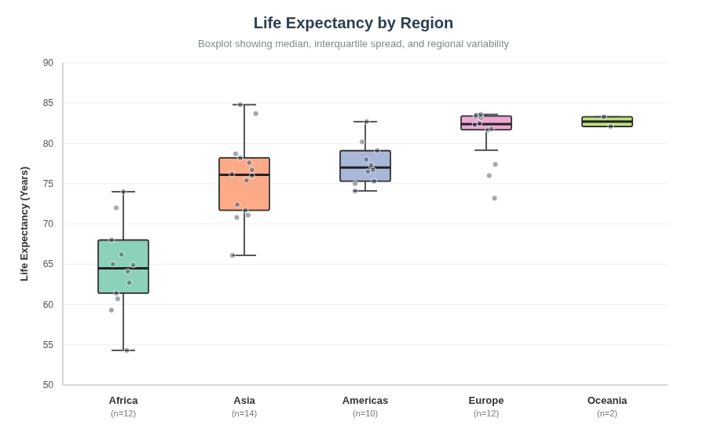

**Figure 2.** Boxplot showing median, interquartile range (IQR), and spread across regions. Individual points depict country observations.

### Distribution Properties & Outlier Diagnostics

As illustrated in **Figure 1**, the distribution of global life expectancy is left-skewed. The majority of countries cluster in the 75–84 year bracket, with the modal frequency occurring between 81 and 84 years. At the lower tail, several nations record life expectancies below 62 years (Nigeria at 54.3 years and Mozambique at 59.3 years), establishing a 30.5-year span across the sample. Because of this lower tail, the median (76.6 years) sits 1.7 years above the arithmetic mean (74.88 years).

The regional boxplot in **Figure 2** highlights clear geographic clustering:

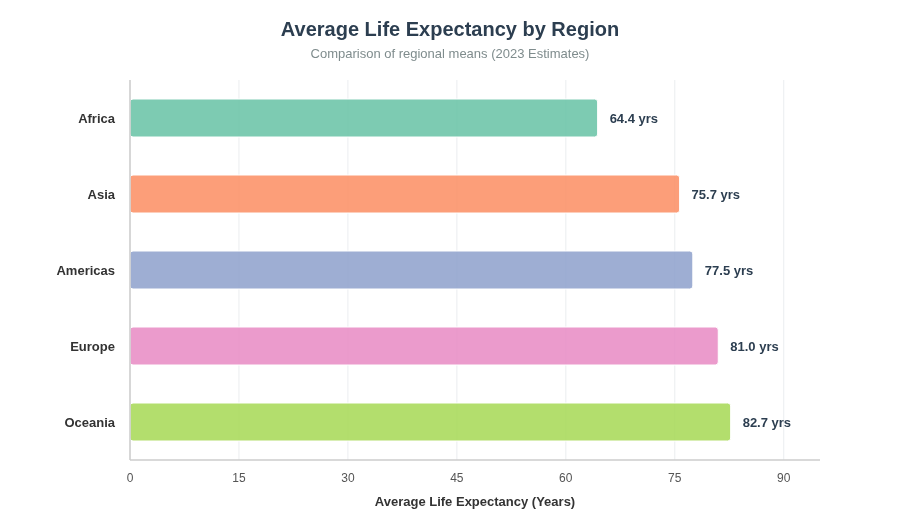

**Figure 3.** Horizontal bar chart of regional mean life expectancies. A gap of 18.3 years separates Oceania from Africa.

### Summary of Regional Disparities

**Figure 3** summarizes the continental division: citizens in European and Oceanian countries live on average 16 to 18 years longer than those in African nations.

> **Observation:** This lifespan disparity directly parallels economic differences: the mean European GDP per capita ($47,381) in the sample is roughly twenty times higher than that of the sampled African nations ($2,266).

## 5. Socioeconomic Associations & Correlation Analysis

Bivariate relationships were evaluated between life expectancy and economic prosperity, healthcare expenditure, and adult literacy rate. All three factors show positive, statistically notable correlations.

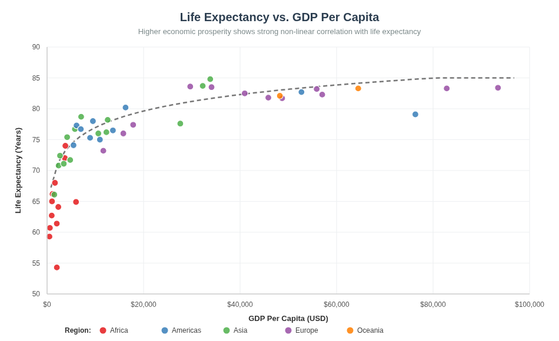

**Figure 4.** Life Expectancy vs. GDP Per Capita with logarithmic trend line (r = +0.694). Gains diminish notably above $30,000.

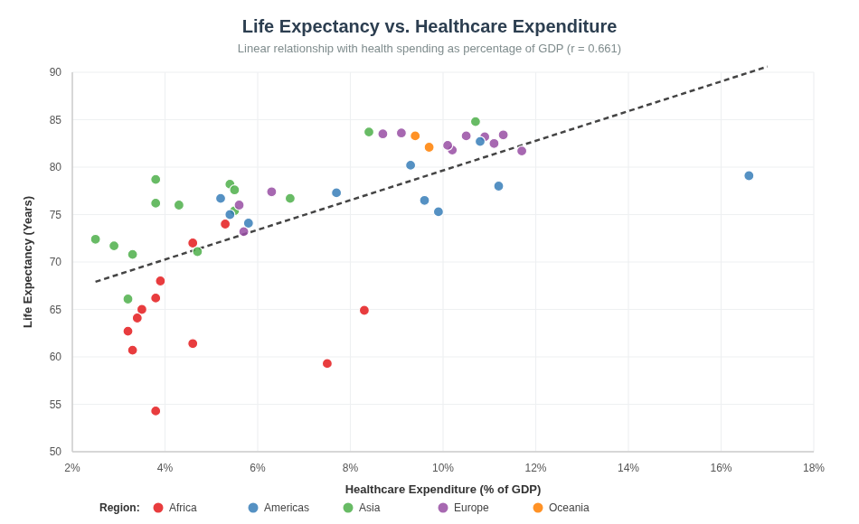

**Figure 5.** Life Expectancy vs. Healthcare Expenditure as % of GDP with linear fit (r = +0.661). Higher spending aligns with longer life.

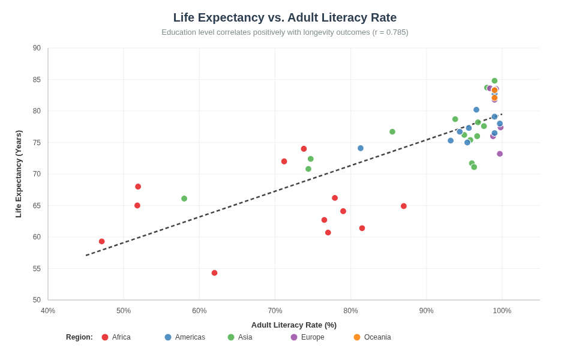

**Figure 6.** Life Expectancy vs. Adult Literacy Rate with linear fit (r = +0.785). Strongest single linear bivariate relationship.

### Correlation Summary

| Indicator Pair | Pearson r | Relationship Type |
| --- | --- | --- |
| Life Exp vs. Adult Literacy | **+0.785** | Strong positive |
| Life Exp vs. GDP Per Capita | **+0.694** | Moderate-to-strong non-linear |
| Life Exp vs. Healthcare Exp % | **+0.661** | Moderate positive |

**The Preston Curve Effect:** In **Figure 4**, the association with GDP per capita is non-linear and concave. At lower income levels (GDP < $10,000), marginal increases in economic output correlate with steep life expectancy gains. Beyond $35,000, returns diminish, and life expectancy plateaus between 81 and 85 years.

## 6. Discussion & Methodological Scope

These observations align with established literature in developmental economics: foundational income, sanitation infrastructure, and basic education are critical prerequisites for maternal health and infectious disease reduction. Adult literacy (r = +0.785) exhibits the strongest linear association, suggesting that educational attainment strongly reinforces health awareness and preventative behaviors.

> **Methodological Scope & Causal Disclaimer:** This study is strictly descriptive and cross-sectional. The observed correlations (r = +0.66 to +0.79) do not establish causal relationships. Confounding variables—such as governance quality, geographical factors, and peacetime stability—simultaneously influence both economic metrics and health outcomes.

## 7. Conclusions

- **Socioeconomic Foundations:** Longevity is closely tied to national economic capacity and foundational education, with literacy rate showing the strongest linear association.
- **Diminishing Economic Returns:** Wealth improvements yield the largest life expectancy gains at lower income thresholds, with plateauing effects observed in high-income economies.
- **Addressing Disparities:** Narrowing the 18.3-year lifespan gap between lower-income regions and developed nations requires coordinated investments in both healthcare capacity and general education.